# Predictors of Religiosity and Spirituality

# Exploratory Data Analysis

In analyzing the self-reported levels of religiosity and spirituality, it is helpful to understand the religious spread of the data. Several of the variables were related to religious identity, including family religion and current religion, so we seeked to plot current religion against self-reported levels of spirituality and religiosity.

First, before trying to plot the data, we noticed that there was a much larger number of those who identified as Catholic, Protestant or Unaffiliated than anything else, so we split the groupings of histograms into two to account for this (then split it again to account for the much larger prevalence of Mormon, Jewish and Other Faith than all the other religious identities combined) so that the spread of each religion across the different values would be clear. This splitting up of the religious categories will prove useful throughout the duration of the EDA section.

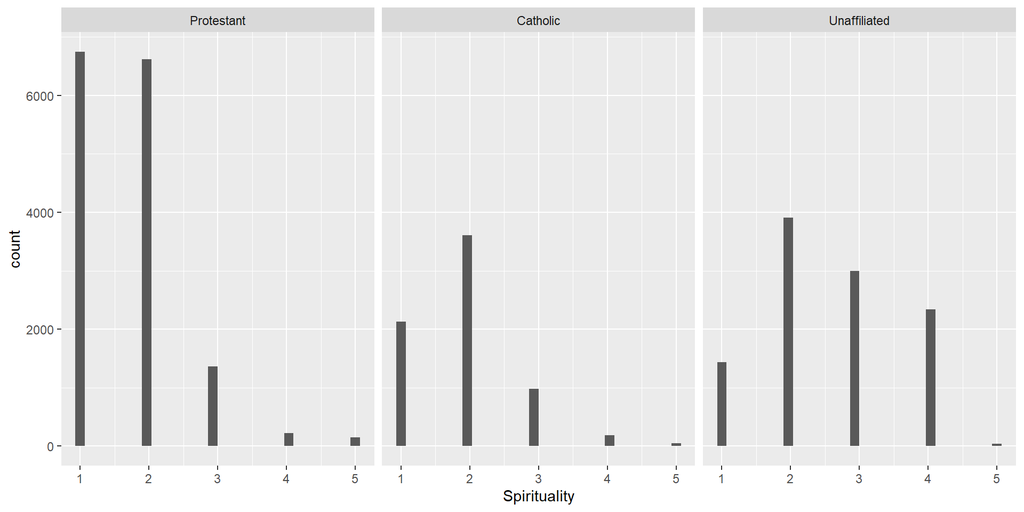

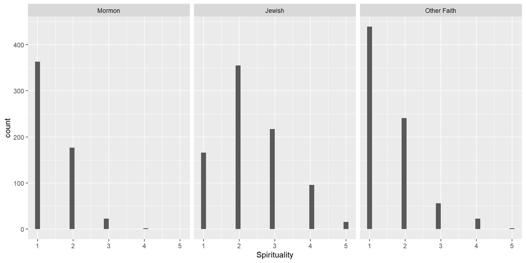

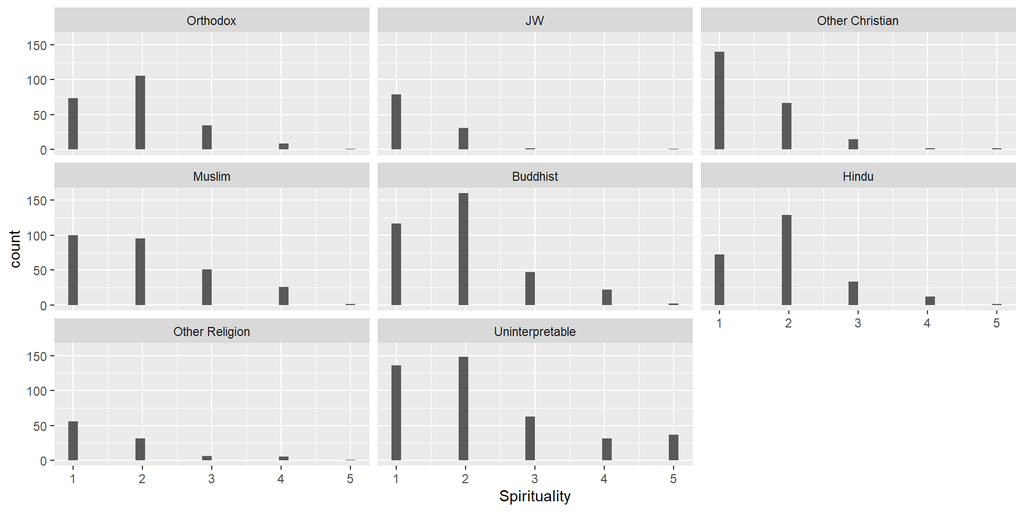

The spread for religiosity is shifted more to the higher (less religious) values than spirituality: there were only two religions where the plurality (largest spike) was 1 (most religious). This difference between the self-reported levels of spirituality and religiosity are striking, as for essentially every religion, levels of spirituality were higher than religiosity. This motivated an analysis of the relationship between spirituality and religiosity, as well as the factors that lead to each variable.

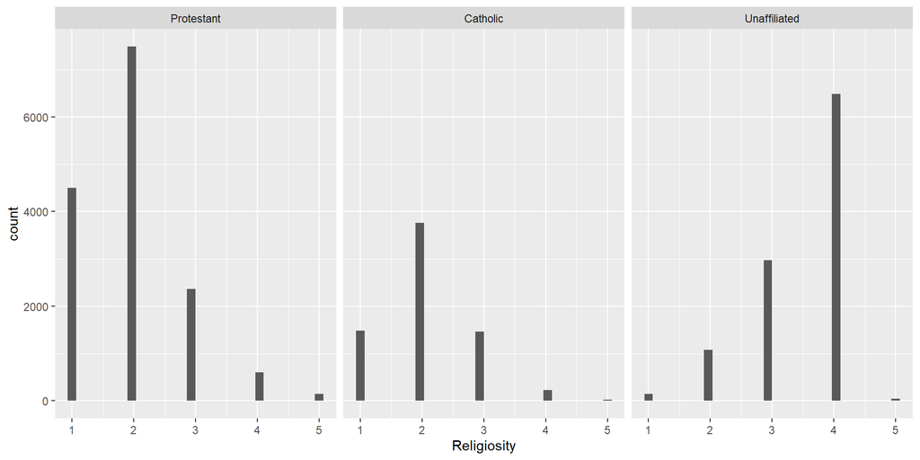

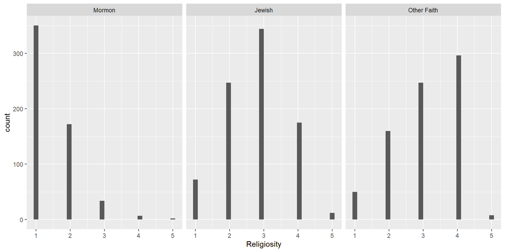

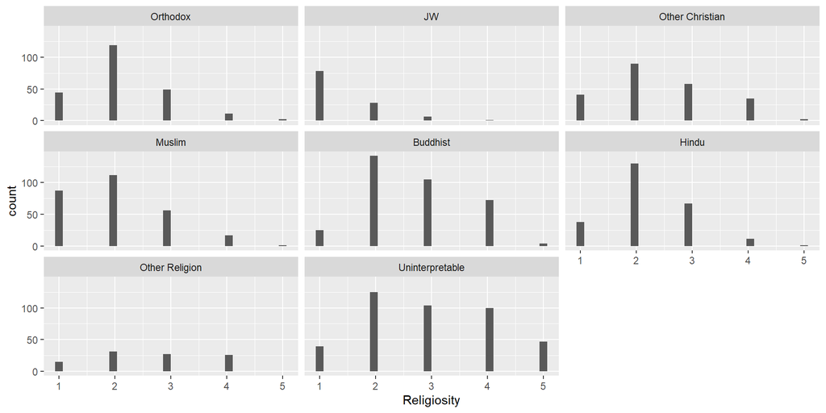

# Statistical Analysis

To formally investigate the relationships suggested by the exploratory data analysis, we apply several statistical methods, including analysis of variance (ANOVA), correlation analysis, simple linear regression, and multiple linear regression. These methods allow us to test for group differences, measure associations between variables, and identify key predictors of religiosity.

## Section 1: Group Differences

We begin by examining whether religiosity differs across religious traditions.

Hypothesis Test:

$H_0$: All religious groups have the same mean religiosity.

$H_a$: At least one group’s mean is different.

```
##                Df Sum Sq Mean Sq F value Pr(>F)
## CURREL         13  17394  1338.0    2247 <2e-16 ***
## Residuals   36590  21785     0.6
## ---
## Signif. codes:  0 '***' 0.001 '**' 0.01 '*' 0.05 '.' 0.1 ' ' 1
```

Summary Statistics by Religious Group

| Current Religion | Mean Religiosity | SD | Sample Size |
| --- | --- | --- | --- |
| JW | 1.380531 | 0.6313051 | 113 |
| Mormon | 1.463588 | 0.6669679 | 563 |
| Protestant | 1.938123 | 0.7856999 | 14949 |
| Muslim | 2.011029 | 0.8823127 | 272 |
| Catholic | 2.063366 | 0.7434991 | 6928 |
| Orthodox | 2.121076 | 0.7761389 | 223 |
| Hindu | 2.207317 | 0.7516698 | 246 |
| Other Christian | 2.388393 | 0.9592828 | 224 |
| Other Religion | 2.646465 | 1.0332545 | 99 |
| Buddhist | 2.651163 | 0.8907355 | 344 |
| Uninterpretable | 2.720109 | 0.9795890 | 368 |
| Jewish | 2.742243 | 0.8841662 | 838 |
| Other Faith | 3.047809 | 0.9327656 | 753 |
| Unaffiliated | 3.478285 | 0.7309605 | 10684 |

The ANOVA results indicate that we reject the null hypothesis, as the p-value is less than 0.05. This suggests that religiosity differs significantly across religious traditions.

To further examine these differences, we computed the mean religiosity score for each group. Religiosity is measured on a scale from 1 (very religious) to 4 (not at all religious), excluding responses coded as 5 (don’t know/refused). Because lower values indicate higher religiosity, groups with lower mean scores are more religious on average. The results show that Protestants have lower mean religiosity scores than Catholics and the unaffiliated, indicating higher average religiosity, while the unaffiliated group reports the highest mean scores, indicating the lowest levels of religiosity.

Protestants, Catholics, and the unaffiliated also have the largest sample sizes, making these estimates more reliable. The standard deviations, which range approximately from 0.5 to 1, suggest a moderate level of variation in religiosity within each group.

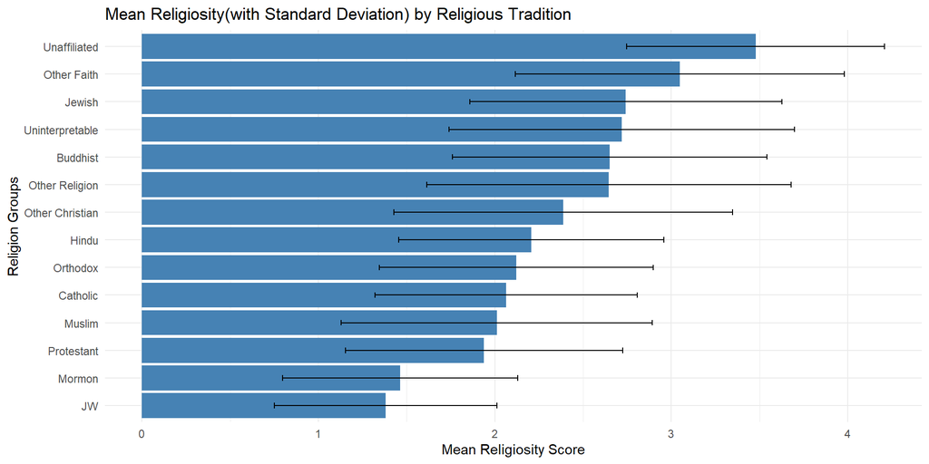

Check Assumptions for ANOVA:

1. Independence
2. Normality within groups
3. Common variance

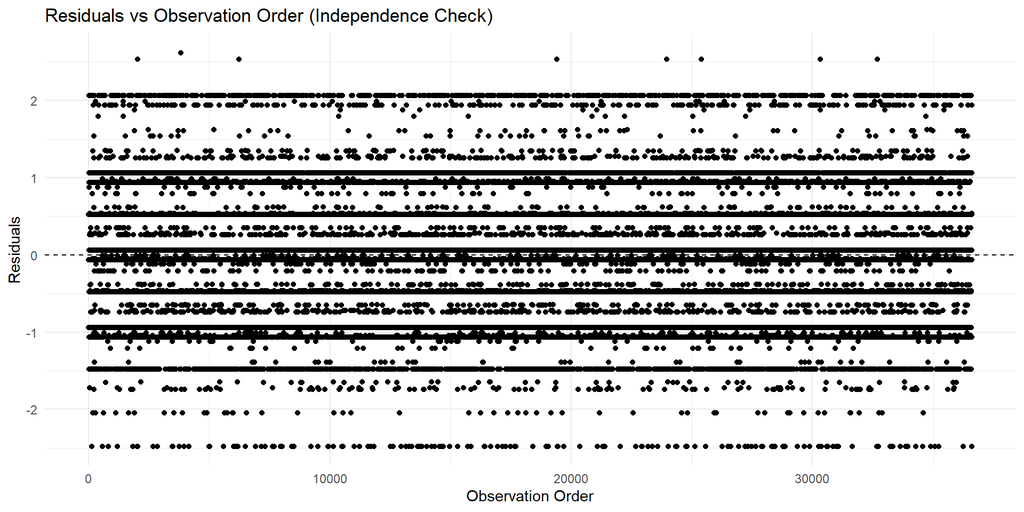

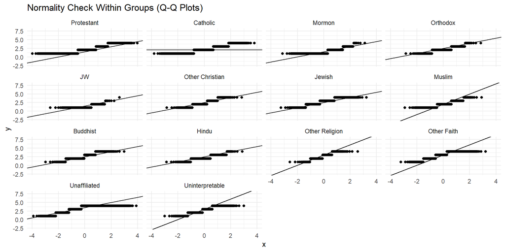

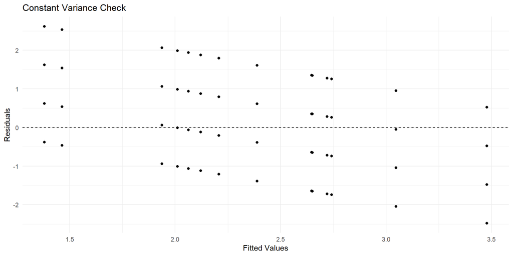

## Section 2: Spirituality vs Religiosity

Next, we examine the relationship between the spirituality and religiosity variables, as the exploratory data analysis suggested that even unaffiliated individuals report relatively high levels of spirituality.

```
## [1] 0.561914
```

```
##
## Call:
## lm(formula = RELPER ~ SPIRPER, data = data_no5)
##
## Residuals:
##     Min      1Q  Median      3Q     Max
## -2.7564 -0.4704 -0.1134  0.5296  2.1726
##
## Coefficients:
##             Estimate Std. Error t value Pr(>|t|)
## (Intercept) 1.184407   0.010869   109.0   <2e-16 ***
## SPIRPER     0.642997   0.004959   129.7   <2e-16 ***
## ---
## Signif. codes:  0 '***' 0.001 '**' 0.01 '*' 0.05 '.' 0.1 ' ' 1
##
## Residual standard error: 0.8557 on 36437 degrees of freedom
## Multiple R-squared:  0.3157, Adjusted R-squared:  0.3157
## F-statistic: 1.681e+04 on 1 and 36437 DF,  p-value: < 2.2e-16
```

A simple linear regression further examined this relationship. The results show that spirituality is a statistically significant predictor of religiosity (p < 0.05). The coefficient indicates that a one-unit increase in spirituality is associated with an increase in religiosity score. The model explains approximately 31.57% ($R^2$ = 0.3157) of the variation in religiosity, suggesting a moderate relationship.

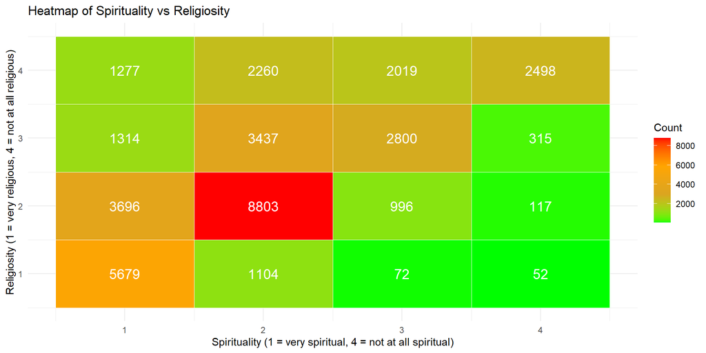

We want to check the assumptions for linear model:

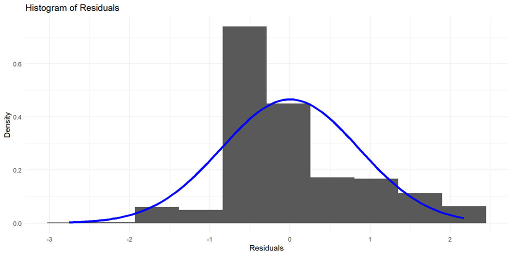

## Section 3: Behavioral Predictors

While spirituality captures internal beliefs, religiosity may also be influenced by observable behaviors such as attendance and prayer. We therefore examine whether these behavioral variables are significant predictors of religiosity.

We focused on four variables here, including frequency of religious service attendance, prayer, scripture reading, and sharing of religious views. We test whether these behavioral factors significantly predict religiosity.

Hypothesis Test:

$H_0$: That none of these behaviors are associated with religiosity.

$H_a$: That at least one behavioral variable significantly predicts religiosity.

```
##
## Call:
## lm(formula = RELPER ~ ATTNDPERRLS + PRAY + PRAC_B + PRAC_D, data = no99)
##
## Residuals:
##      Min       1Q   Median       3Q      Max
## -2.61517 -0.40885 -0.05211  0.40467  2.84929
##
## Coefficients:
##              Estimate Std. Error t value Pr(>|t|)
## (Intercept)  0.705294   0.012384  56.953   <2e-16 ***
## ATTNDPERRLS  0.215591   0.003086  69.868   <2e-16 ***
## PRAY         0.186483   0.002190  85.169   <2e-16 ***
## PRAC_B       0.063182   0.003543  17.833   <2e-16 ***
## PRAC_D      -0.004961   0.003687  -1.345    0.178
## ---
## Signif. codes:  0 '***' 0.001 '**' 0.01 '*' 0.05 '.' 0.1 ' ' 1
##
## Residual standard error: 0.6659 on 35842 degrees of freedom
## Multiple R-squared:  0.5856, Adjusted R-squared:  0.5855
## F-statistic: 1.266e+04 on 4 and 35842 DF,  p-value: < 2.2e-16
```

The results from the full model indicate that attendance, prayer frequency, and scripture reading are statistically significant predictors of religiosity (p < 0.05). Because religiosity is reverse-coded (higher values = lower religiosity), the positive coefficients indicate that more frequent religious behaviors are associated with lower religiosity scores, that is higher actual religiosity. In contrast, sharing beliefs (PRAC_D) is not statistically significant, suggesting that sharing religious views with others does not have a measurable relationship with religiosity in this model.

The model explains approximately 58.56% ($R^2$ = 0.5856) of the variation in religiosity, indicating a relatively strong relationship between behavioral practices and religiosity.

After checking the total group model, we focus on Protestant, Catholic, and Unaffiliated groups because they have the largest sample sizes in the dataset, which provides more reliable and stable estimates. While core practices such as prayer and attendance are strong predictors of religiosity in the Muslim subsample, other behaviors such as scripture reading and sharing beliefs are not statistically significant, suggesting that the relationship between behavior and religiosity is selective rather than uniform.

### Protestant Group

```
##
## Call:
## lm(formula = RELPER ~ ATTNDPERRLS + PRAY + PRAC_B + PRAC_D, data = protestant_data)
##
## Residuals:
##     Min      1Q  Median      3Q     Max
## -1.8208 -0.4932 -0.0820  0.3761  2.6364
##
## Coefficients:
##             Estimate Std. Error t value Pr(>|t|)
## (Intercept) 1.054964   0.016932  62.307  < 2e-16 ***
## ATTNDPERRLS 0.119634   0.004542  26.341  < 2e-16 ***
## PRAY        0.102805   0.004215  24.391  < 2e-16 ***
## PRAC_B      0.067325   0.005328  12.637  < 2e-16 ***
## PRAC_D      0.018922   0.005331   3.549 0.000387 ***
## ---
## Signif. codes:  0 '***' 0.001 '**' 0.01 '*' 0.05 '.' 0.1 ' ' 1
##
## Residual standard error: 0.669 on 14560 degrees of freedom
## Multiple R-squared:  0.2734, Adjusted R-squared:  0.2732
## F-statistic:  1370 on 4 and 14560 DF,  p-value: < 2.2e-16
```

The results from the Protestant model indicate that attendance (ATTNDPERRLS), prayer frequency (PRAY), scripture reading (PRAC_B), and sharing religious views (PRAC_D) are statistically significant predictors of religiosity (p < 0.05). Given the coding of religiosity, where higher values indicate lower levels of religiosity, these results suggest that more frequent religious practices are associated with lower religiosity scores, indicating higher levels of religious engagement.

The model explains approximately 27.34% ($R^2$ = 0.2734) of the variation in religiosity, suggesting a moderate relationship between behavioral practices and religiosity within the Protestant subsample.

### Catholic Group

```
##
## Call:
## lm(formula = RELPER ~ ATTNDPERRLS + PRAY + PRAC_B + PRAC_D, data = catholic_data)
##
## Residuals:
##     Min      1Q  Median      3Q     Max
## -2.1253 -0.3578 -0.0318  0.3484  2.8866
##
## Coefficients:
##             Estimate Std. Error t value Pr(>|t|)
## (Intercept) 0.679348   0.025274  26.879  < 2e-16 ***
## ATTNDPERRLS 0.174389   0.005501  31.700  < 2e-16 ***
## PRAY        0.129122   0.004237  30.475  < 2e-16 ***
## PRAC_B      0.067755   0.006135  11.044  < 2e-16 ***
## PRAC_D      0.031407   0.007179   4.375 1.23e-05 ***
## ---
## Signif. codes:  0 '***' 0.001 '**' 0.01 '*' 0.05 '.' 0.1 ' ' 1
##
## Residual standard error: 0.5383 on 6809 degrees of freedom
## Multiple R-squared:  0.4764, Adjusted R-squared:  0.4761
## F-statistic:  1549 on 4 and 6809 DF,  p-value: < 2.2e-16
```

The results from the Catholic model indicate that attendance (ATTNDPERRLS), prayer frequency (PRAY), scripture reading (PRAC_B), and sharing religious views (PRAC_D) are statistically significant predictors of religiosity (p < 0.05). Given the coding of religiosity, where higher values indicate lower levels of religiosity, these results suggest that more frequent religious practices are associated with lower religiosity scores, indicating higher levels of religious engagement.

The model explains approximately 47.64% ($R^2$ = 0.4764) of the variation in religiosity, suggesting a relatively strong relationship between behavioral practices and religiosity within the Catholic subsample.

### Muslim Group

```
##
## Call:
## lm(formula = RELPER ~ ATTNDPERRLS + PRAY + PRAC_B + PRAC_D, data = muslim_data)
##
## Residuals:
##      Min       1Q   Median       3Q      Max
## -1.90472 -0.51176 -0.07219  0.41528  2.37060
##
## Coefficients:
##             Estimate Std. Error t value Pr(>|t|)
## (Intercept)  0.85483    0.13110   6.521 3.54e-10 ***
## ATTNDPERRLS  0.13021    0.02980   4.369 1.79e-05 ***
## PRAY         0.16148    0.02480   6.512 3.72e-10 ***
## PRAC_B       0.06696    0.03438   1.948   0.0525 .
## PRAC_D       0.02527    0.03519   0.718   0.4732
## ---
## Signif. codes:  0 '***' 0.001 '**' 0.01 '*' 0.05 '.' 0.1 ' ' 1
##
## Residual standard error: 0.6871 on 264 degrees of freedom
## Multiple R-squared:  0.4063, Adjusted R-squared:  0.3973
## F-statistic: 45.16 on 4 and 264 DF,  p-value: < 2.2e-16
```

The results from the Muslim model indicate that attendance (ATTNDPERRLS) and prayer frequency (PRAY) are statistically significant predictors of religiosity (p < 0.05). Given the coding of religiosity, where higher values indicate lower levels of religiosity, these results suggest that more frequent religious practices are associated with lower religiosity scores, indicating higher levels of religious engagement. In contrast, scripture reading (PRAC_B) and sharing beliefs (PRAC_D) is not statistically significant, suggesting that these two behaviors does not have a measurable relationship with religiosity in this model.

The model explains approximately 40.63% ($R^2$ = 0.4063) of the variation in religiosity, suggesting a moderate to relatively strong relationship between behavioral practices and religiosity within the Muslim subsample.

### Unaffiliated Group

```
##
## Call:
## lm(formula = RELPER ~ ATTNDPERRLS + PRAY + PRAC_B + PRAC_D, data = unaffil_data)
##
## Residuals:
##     Min      1Q  Median      3Q     Max
## -2.8749 -0.3659  0.1711  0.3101  2.5644
##
## Coefficients:
##              Estimate Std. Error t value Pr(>|t|)
## (Intercept)  0.818845   0.044116  18.561  < 2e-16 ***
## ATTNDPERRLS  0.227620   0.007980  28.524  < 2e-16 ***
## PRAY         0.161981   0.003658  44.286  < 2e-16 ***
## PRAC_B       0.125079   0.008699  14.379  < 2e-16 ***
## PRAC_D      -0.022988   0.006884  -3.339 0.000843 ***
## ---
## Signif. codes:  0 '***' 0.001 '**' 0.01 '*' 0.05 '.' 0.1 ' ' 1
##
## Residual standard error: 0.5709 on 10515 degrees of freedom
## Multiple R-squared:  0.3884, Adjusted R-squared:  0.3881
## F-statistic:  1669 on 4 and 10515 DF,  p-value: < 2.2e-16
```

The results from the Unaffiliated model indicate that some behavioral variables are statistically significant predictors of religiosity (p < 0.05). Given the coding of religiosity, where higher values indicate lower levels of religiosity, these results suggest that more frequent religious practices are associated with lower religiosity scores, indicating higher levels of religious engagement.

The model explains approximately 38.84% ($R^2$ = 0.3884) of the variation in religiosity, suggesting a moderate relationship between behavioral practices and religiosity within the Unaffiliated subsample.

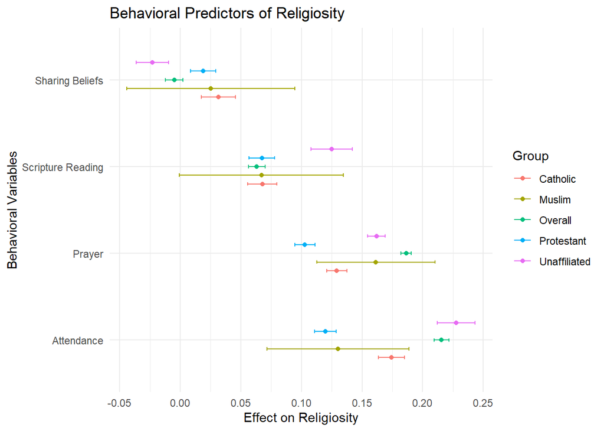

The coefficient plot compares the effects of behavioral predictors on religiosity across different religious groups. Each point represents the estimated effect size, with horizontal bars indicating 95% confidence intervals. Attendance and prayer consistently exhibit the largest effect sizes across all groups, indicating that these core religious practices are the most robust behavioral predictors of religiosity. In contrast, scripture reading has a smaller but still positive effect, while sharing beliefs shows the greatest variability across groups, including weak or insignificant effects in some cases. Overall, the results indicate that while core devotional practices are strong and stable predictors of religiosity across groups, the influence of interpersonal religious expression varies considerably.

We want to check the assumptions for linear model:

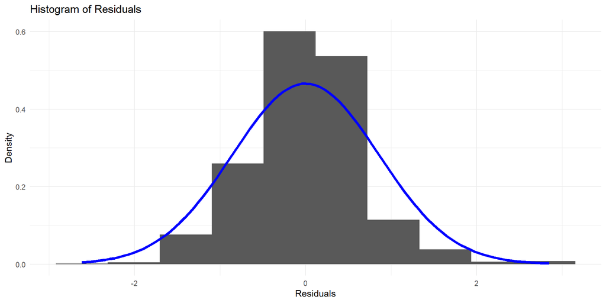

We estimate separate models by religious group to examine whether the relationship between behavioral practices and religiosity varies across traditions. Prior research suggests that religious expression differs across groups—for example, Protestant traditions often emphasize personal faith expression, while Catholic practice may be more institutionally structured, and Islamic religiosity is often closely tied to prescribed practices. By estimating subgroup models, we can test whether behavioral predictors have different magnitudes or significance across these contexts.

## Section 4: Political Predictors of Religiosity

Religious groups are frequently cited as key voting groups. Notably, there has been recent conflation of “Evangelicals” the voting group with *Evangelicalism* the religious group within Protestantism. This data aims to determine if socio-political predictions can be used to predict religiosity within the sampled set.

$H_0$: Stances on all cultural and political issues will have equal slopes

$H_a$: At least one of these issue’s explains variance in the data set

```
##
## Call:
## lm(formula = Religiosity ~ Abortion_Legality + Gay_Marriage_Support +
##     Transgender_Acceptance + Immigrant_Impact + Racial_Diversity +
##     Relig_Diversity + Homosexuality_Acceptance + Environmental_Regulation,
##     data = data_clean)
##
## Residuals:
##     Min      1Q  Median      3Q     Max
## -2.2350 -0.6717 -0.1007  0.8422  3.6671
##
## Coefficients:
##                           Estimate Std. Error t value Pr(>|t|)
## (Intercept)               3.659832   0.034512 106.045  < 2e-16 ***
## Abortion_Legality        -0.248656   0.006830 -36.408  < 2e-16 ***
## Gay_Marriage_Support     -0.294932   0.008219 -35.883  < 2e-16 ***
## Transgender_Acceptance   -0.070268   0.007552  -9.305  < 2e-16 ***
## Immigrant_Impact         -0.019873   0.006866  -2.894   0.0038 **
## Racial_Diversity          0.040571   0.007830   5.181 2.22e-07 ***
## Relig_Diversity          -0.001957   0.007008  -0.279   0.7801
## Homosexuality_Acceptance -0.013841   0.016955  -0.816   0.4143
## Environmental_Regulation  0.053459   0.011803   4.529 5.94e-06 ***
## ---
## Signif. codes:  0 '***' 0.001 '**' 0.01 '*' 0.05 '.' 0.1 ' ' 1
##
## Residual standard error: 0.915 on 33877 degrees of freedom
## Multiple R-squared:  0.2458, Adjusted R-squared:  0.2456
## F-statistic:  1380 on 8 and 33877 DF,  p-value: < 2.2e-16
```

With the null values (99s) removed we see that there is substantial evidence to reject the null hypothesis. P-values for individual variables also indicate that there is statistical relation between the variables and religiosity. Six of the eight variables are significant at the 0.05 level. The effect of increasing religious diversity and support for acceptance of homosexuality in society do not meet the threshold for significance.

Our adjusted $R^2$ was .2456, meaning that approximately 75% of the variation cannot be explained by this data. While we see substantial benefit to this model, there is still unexplained error and thus improvement which can be made.

```
##
## Call:
## lm(formula = Religiosity ~ Abortion_Legality + Gay_Marriage_Support +
##     Transgender_Acceptance + Immigrant_Impact + Racial_Diversity +
##     Environmental_Regulation, data = data_clean)
##
## Residuals:
##     Min      1Q  Median      3Q     Max
## -2.2373 -0.6720 -0.1005  0.8417  3.6674
##
## Coefficients:
##                           Estimate Std. Error t value Pr(>|t|)
## (Intercept)               3.649504   0.032362 112.771  < 2e-16 ***
## Abortion_Legality        -0.249309   0.006779 -36.775  < 2e-16 ***
## Gay_Marriage_Support     -0.299202   0.006472 -46.228  < 2e-16 ***
## Transgender_Acceptance   -0.070219   0.007515  -9.344  < 2e-16 ***
## Immigrant_Impact         -0.019865   0.006827  -2.910  0.00362 **
## Racial_Diversity          0.039481   0.007039   5.609 2.05e-08 ***
## Environmental_Regulation  0.053964   0.011788   4.578 4.71e-06 ***
## ---
## Signif. codes:  0 '***' 0.001 '**' 0.01 '*' 0.05 '.' 0.1 ' ' 1
##
## Residual standard error: 0.915 on 33879 degrees of freedom
## Multiple R-squared:  0.2458, Adjusted R-squared:  0.2456
## F-statistic:  1840 on 6 and 33879 DF,  p-value: < 2.2e-16
```

In an attempt to improve the model, support for homosexuality in society and impact of increasing religious diversity were removed. There was no absolute difference in $R^2$, with the adjusted value remaining 0.2456.

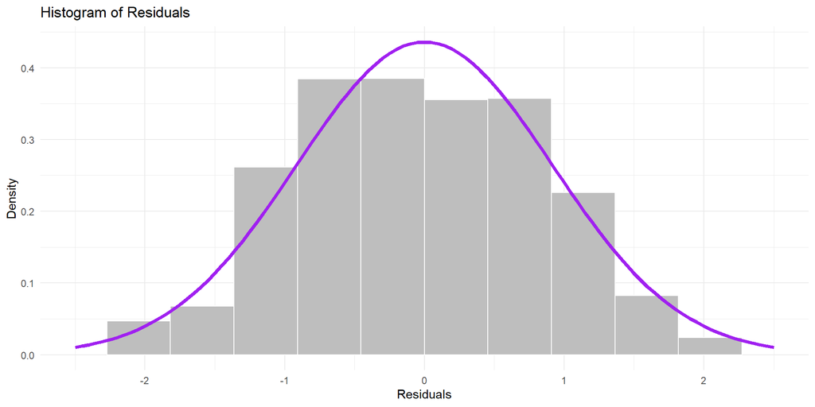

As mentioned in section 3, assumed normality can be checked based on the residuals being fit versus a normal curve. The overlaid normal curve bears some resemblance to the fitted residuals, but there is more slight variation from predicted than exact values. Discrete data points may be a significant contributor to this effect. However, the symmetry present does encourage us to continue with the assumption that normality can be reasonably assumed.

### Protestant Group

The model can be computed for Protestants alone:

```
##
## Call:
## lm(formula = Religiosity ~ Abortion_Legality + Gay_Marriage_Support +
##     Transgender_Acceptance + Immigrant_Impact + Racial_Diversity +
##     Relig_Diversity + Homosexuality_Acceptance + Environmental_Regulation,
##     data = protestant_data)
##
## Residuals:
##     Min      1Q  Median      3Q     Max
## -1.3973 -0.6222 -0.0777  0.3152  3.4621
##
## Coefficients:
##                           Estimate Std. Error t value Pr(>|t|)
## (Intercept)               2.630255   0.046607  56.434  < 2e-16 ***
## Abortion_Legality        -0.094701   0.009158 -10.341  < 2e-16 ***
## Gay_Marriage_Support     -0.134905   0.010571 -12.762  < 2e-16 ***
## Transgender_Acceptance   -0.006775   0.010803  -0.627  0.53059
## Immigrant_Impact          0.013297   0.010182   1.306  0.19159
## Racial_Diversity          0.017426   0.009658   1.804  0.07122 .
## Relig_Diversity           0.002701   0.009585   0.282  0.77812
## Homosexuality_Acceptance -0.060769   0.021065  -2.885  0.00392 **
## Environmental_Regulation -0.036112   0.015070  -2.396  0.01657 *
## ---
## Signif. codes:  0 '***' 0.001 '**' 0.01 '*' 0.05 '.' 0.1 ' ' 1
##
## Residual standard error: 0.7934 on 13550 degrees of freedom
## Multiple R-squared:  0.07448,    Adjusted R-squared:  0.07393
## F-statistic: 136.3 on 8 and 13550 DF,  p-value: < 2.2e-16
```

Estimating Protestant religiosity with this data was not successful. Only 7% of varaition could be explained using these variables ($R^2$ = 0.07393). Half (four) of the variables achieved significance at the 95% level.

```
##
## Call:
## lm(formula = Religiosity ~ Abortion_Legality + Gay_Marriage_Support +
##     Homosexuality_Acceptance + Environmental_Regulation, data = protestant_data)
##
## Residuals:
##     Min      1Q  Median      3Q     Max
## -1.3474 -0.6056 -0.0796  0.2990  3.4351
##
## Coefficients:
##                           Estimate Std. Error t value Pr(>|t|)
## (Intercept)               2.675808   0.038361  69.753  < 2e-16 ***
## Abortion_Legality        -0.095356   0.009154 -10.417  < 2e-16 ***
## Gay_Marriage_Support     -0.131738   0.010319 -12.766  < 2e-16 ***
## Homosexuality_Acceptance -0.060564   0.021051  -2.877  0.00402 **
## Environmental_Regulation -0.040705   0.014870  -2.737  0.00620 **
## ---
## Signif. codes:  0 '***' 0.001 '**' 0.01 '*' 0.05 '.' 0.1 ' ' 1
##
## Residual standard error: 0.7935 on 13554 degrees of freedom
## Multiple R-squared:  0.074,  Adjusted R-squared:  0.07373
## F-statistic: 270.8 on 4 and 13554 DF,  p-value: < 2.2e-16
```

Removing the variables that were did not achieve significance the model was remade, but with poor results. Less variation was explained with the model than with all eight variables ($R^2$ = 0.07373)

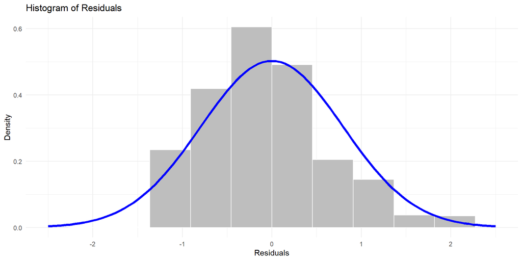

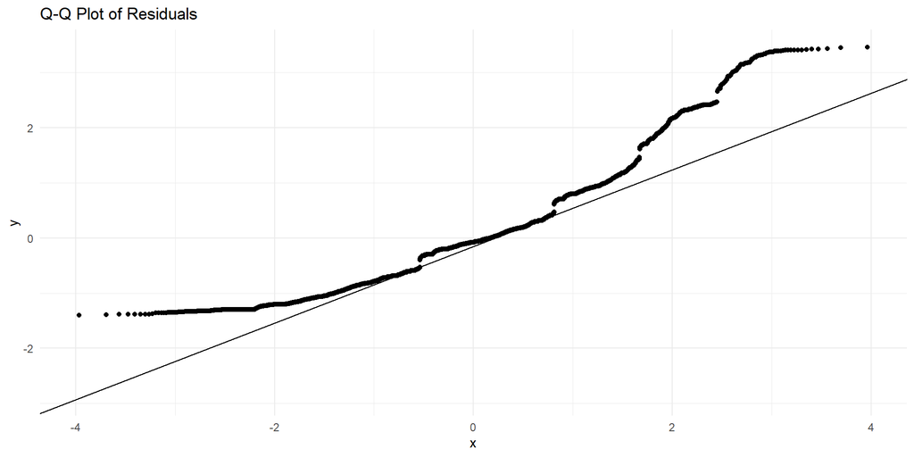

Fitting a normal curve to the residuals, the overlaid normal curve does nicely map onto our observed data. However, we do notice that it is slightly right-tailed. However, the majority of individuals seem to fit well within the model.

The Q-Q plote tells us that there is a major issue with the normality assumption. Returning to the histogram we can observe that the model is actually underpredicting religiosity. A negative residual means that the actual religiosity value was lower than our model calculated. One possible reason for this could be that religous Protestants are more progressive on social issues and consider themselves more religious than our model predicts.

### Catholic Group

```
##
## Call:
## lm(formula = Religiosity ~ Abortion_Legality + Gay_Marriage_Support +
##     Transgender_Acceptance + Immigrant_Impact + Racial_Diversity +
##     Relig_Diversity + Homosexuality_Acceptance + Environmental_Regulation,
##     data = catholic_data)
##
## Residuals:
##     Min      1Q  Median      3Q     Max
## -1.6771 -0.4755 -0.0965  0.4853  3.4780
##
## Coefficients:
##                          Estimate Std. Error t value Pr(>|t|)
## (Intercept)               2.85679    0.05945  48.055  < 2e-16 ***
## Abortion_Legality        -0.22623    0.01135 -19.927  < 2e-16 ***
## Gay_Marriage_Support     -0.15274    0.01422 -10.744  < 2e-16 ***
## Transgender_Acceptance   -0.01679    0.01245  -1.349 0.177377
## Immigrant_Impact          0.01991    0.01230   1.618 0.105679
## Racial_Diversity          0.04885    0.01349   3.622 0.000295 ***
## Relig_Diversity           0.01258    0.01182   1.064 0.287494
## Homosexuality_Acceptance  0.01115    0.02834   0.393 0.693994
## Environmental_Regulation -0.03902    0.01971  -1.979 0.047828 *
## ---
## Signif. codes:  0 '***' 0.001 '**' 0.01 '*' 0.05 '.' 0.1 ' ' 1
##
## Residual standard error: 0.6993 on 6309 degrees of freedom
## Multiple R-squared:  0.1585, Adjusted R-squared:  0.1574
## F-statistic: 148.5 on 8 and 6309 DF,  p-value: < 2.2e-16
```

Like the other socio-political models built, modeling Catholic respondents alone achieved significance at the 95% confidence level. Four variables did not achieve significance with p-values above 0.05. Effect of increasing religious diversity, acceptance of homosexuality in society, acceptance for transgender identity, and effect of immigration were not shown to be statistically significant at the 0.05 level.

The model did not provide an incredible amount of information. With an $R^2$ of 0.1574, the vast majority of the variance (>80%) could not be explained with the tested variables.

```
##
## Call:
## lm(formula = Religiosity ~ Abortion_Legality + Gay_Marriage_Support +
##     Racial_Diversity + Environmental_Regulation, data = catholic_data)
##
## Residuals:
##     Min      1Q  Median      3Q     Max
## -1.6385 -0.4864 -0.1093  0.5136  3.4930
##
## Coefficients:
##                          Estimate Std. Error t value Pr(>|t|)
## (Intercept)               2.88809    0.05003  57.729  < 2e-16 ***
## Abortion_Legality        -0.22733    0.01126 -20.180  < 2e-16 ***
## Gay_Marriage_Support     -0.14981    0.01169 -12.813  < 2e-16 ***
## Racial_Diversity          0.05590    0.01191   4.693 2.75e-06 ***
## Environmental_Regulation -0.04020    0.01959  -2.053   0.0402 *
## ---
## Signif. codes:  0 '***' 0.001 '**' 0.01 '*' 0.05 '.' 0.1 ' ' 1
##
## Residual standard error: 0.6994 on 6313 degrees of freedom
## Multiple R-squared:  0.1578, Adjusted R-squared:  0.1572
## F-statistic: 295.6 on 4 and 6313 DF,  p-value: < 2.2e-16
```

Removing the four variables which did not achieve significance, the model was remade, yielding an $R^2$ of 0.1572, practically identical to that of the model built with all eight variables.

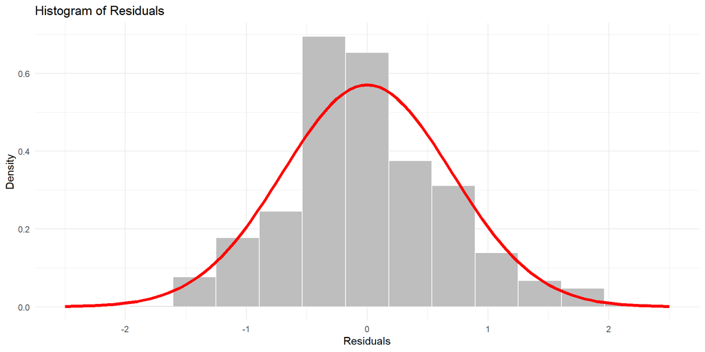

The histogram represents a generally normal curve with the exception of some odd residuals which are underpredicting religiosity based on the answers to these questions.

### Unaffiliated Group

```
##
## Call:
## lm(formula = Religiosity ~ Abortion_Legality + Gay_Marriage_Support +
##     Transgender_Acceptance + Immigrant_Impact + Racial_Diversity +
##     Relig_Diversity + Homosexuality_Acceptance + Environmental_Regulation,
##     data = unaffiliated_data)
##
## Residuals:
##     Min      1Q  Median      3Q     Max
## -2.7372 -0.4742  0.2628  0.4130  2.2463
##
## Coefficients:
##                            Estimate Std. Error t value Pr(>|t|)
## (Intercept)               3.7617888  0.0553673  67.942  < 2e-16 ***
## Abortion_Legality        -0.1331101  0.0106751 -12.469  < 2e-16 ***
## Gay_Marriage_Support     -0.1502648  0.0135916 -11.056  < 2e-16 ***
## Transgender_Acceptance   -0.0649723  0.0103641  -6.269 3.78e-10 ***
## Immigrant_Impact         -0.0226259  0.0086589  -2.613  0.00899 **
## Racial_Diversity         -0.0124379  0.0124207  -1.001  0.31666
## Relig_Diversity           0.0001199  0.0097659   0.012  0.99020
## Homosexuality_Acceptance  0.0003028  0.0307538   0.010  0.99215
## Environmental_Regulation  0.1792118  0.0186957   9.586  < 2e-16 ***
## ---
## Signif. codes:  0 '***' 0.001 '**' 0.01 '*' 0.05 '.' 0.1 ' ' 1
##
## Residual standard error: 0.6832 on 10220 degrees of freedom
## Multiple R-squared:  0.1173, Adjusted R-squared:  0.1166
## F-statistic: 169.8 on 8 and 10220 DF,  p-value: < 2.2e-16
```

```
##
## Call:
## lm(formula = Religiosity ~ Abortion_Legality + Gay_Marriage_Support +
##     Transgender_Acceptance + Immigrant_Impact + Environmental_Regulation,
##     data = unaffiliated_data)
##
## Residuals:
##     Min      1Q  Median      3Q     Max
## -2.7373 -0.4709  0.2627  0.4153  2.2602
##
## Coefficients:
##                          Estimate Std. Error t value Pr(>|t|)
## (Intercept)               3.74884    0.04786  78.335  < 2e-16 ***
## Abortion_Legality        -0.13353    0.01066 -12.525  < 2e-16 ***
## Gay_Marriage_Support     -0.15252    0.01114 -13.691  < 2e-16 ***
## Transgender_Acceptance   -0.06644    0.01025  -6.482 9.48e-11 ***
## Immigrant_Impact         -0.02395    0.00853  -2.808    0.005 **
## Environmental_Regulation  0.18243    0.01842   9.906  < 2e-16 ***
## ---
## Signif. codes:  0 '***' 0.001 '**' 0.01 '*' 0.05 '.' 0.1 ' ' 1
##
## Residual standard error: 0.6832 on 10223 degrees of freedom
## Multiple R-squared:  0.1172, Adjusted R-squared:  0.1168
## F-statistic: 271.5 on 5 and 10223 DF,  p-value: < 2.2e-16
```

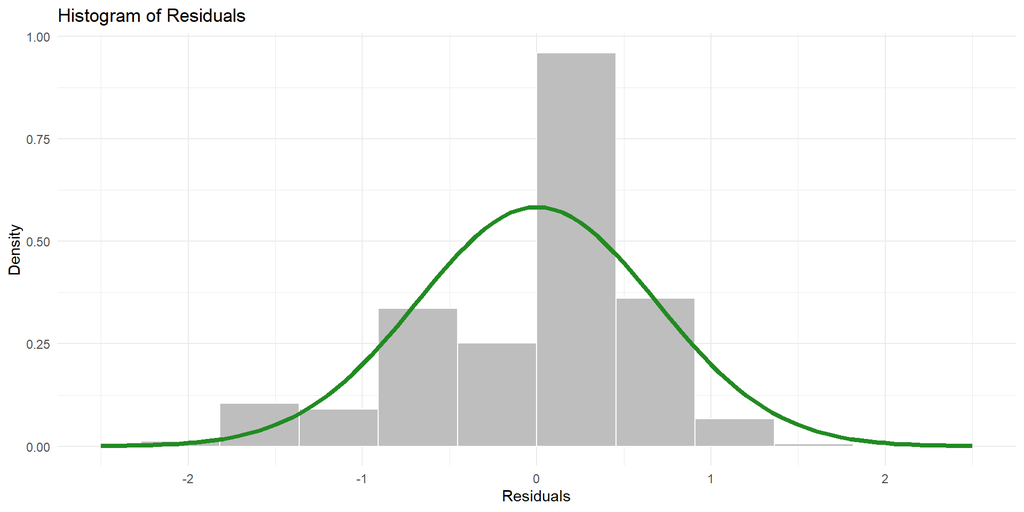

**Display of Calculated Coefficients**

[output not shown]

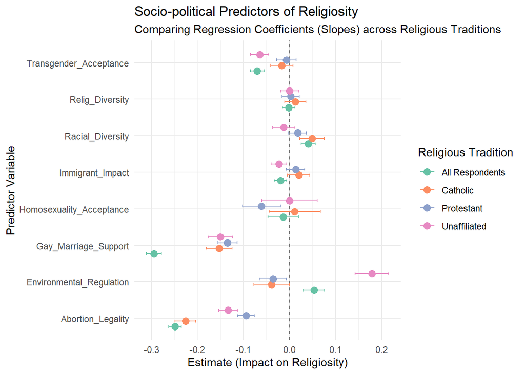

From this figure, we see that there is inter-religious difference with regards to variables being significant in some religious group and not in others and sometimes, such as with support for gay marriage, the overall is significantly different from the three specific groups. For example, Transgender acceptance is a statistically significant predictor of religiosity among unaffiliated people but not within Catholics or Protestants. This contrasts with the overall relation which suggested quite a strong inverse relationship. Environmental regulation is another example. While Catholics and Protestants have similar relationships with religiosity and environmental regulation, the general public and unaffiliated groups do not resemble the two Christian group values.

## Section 5: Comprehensive Model

Finally, using 25 variables (not including current religion, which is completely collinear with religious tradition) we construct a comprehensive linear model that incorporates behavioral measures, belief variables, and religious affiliation to determine which factors are most important in predicting religiosity and how much of the variance of self-reported levels of religiosity can be explained by these predictors.

With an $R^2$ of 0.6645, this model can account for 66% of variance through the variables that we presented it with. The $R^2$ for spirituality was quite a bit lower, however, with an $R^2$ of just .4346, meaning that those same variables were worse at accounting for the variance in response of self-reported levels of spirituality.

Checking the assumptions for regression, we see that the residuals for the spirituality model are normally distributed:

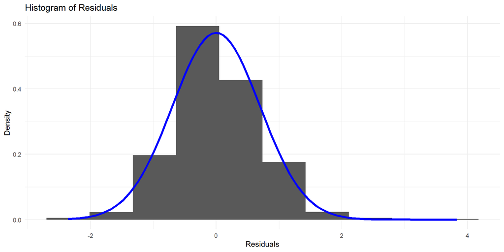

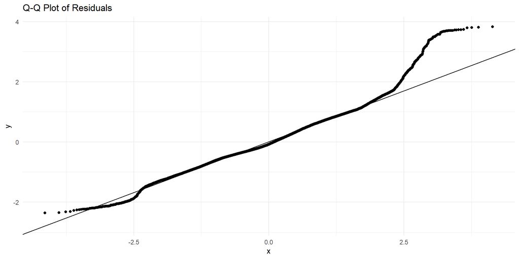

The same is true of the religiosity model:

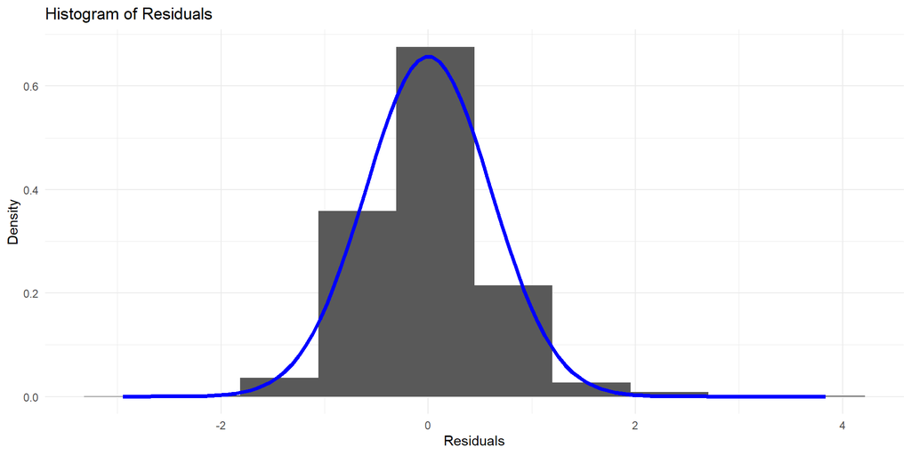

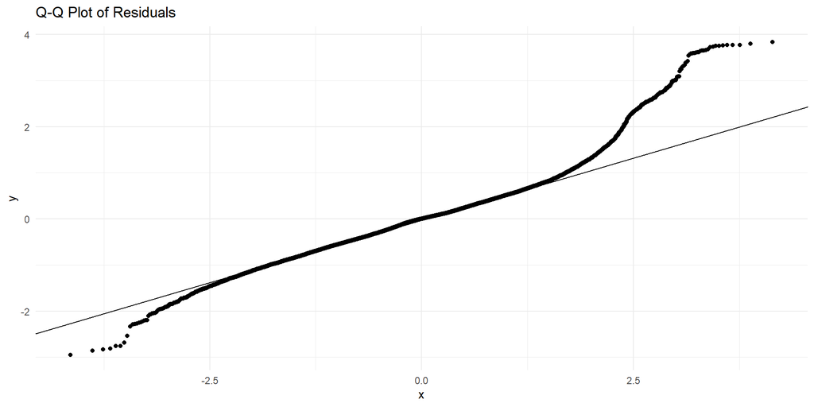

Looking at the p-values for the religiosity model, there were a few variables that were not impactful in predicting religiosity. These included those related to family religion, marital status, birth decade, race and ethnicity, voter registration, current school enrollment status, and immigration status. When these variables were removed, the $R^2$ value decreased to .6622, which is practically the same. The spirituality model had just five variables with a high p-value, which interestingly included those related to belief in Hell (but not Heaven or God) and opinions on the legalization of abortion. Other variables with high p-values included marital status, race and ethnicity.

# Conclusions

Across both the full sample and some religious subsamples, behavioral factors—including attendance, prayer frequency, and scripture reading—consistently emerge as significant predictors of religiosity. These findings suggest that religiosity is strongly shaped by observable religious practices, rather than being solely an internal belief system. However, the strength of these relationships varies across religious traditions. The Catholic and Muslim subsamples show relatively stronger explanatory power, while the Protestant model shows a weaker relationship between behaviors and religiosity. The Unaffiliated group also demonstrates that behavioral practices remain relevant even in the absence of formal religious affiliation. Overall, the results indicate that religiosity is best understood as a behaviorally structured phenomenon, but the degree to which behavior predicts religiosity differs across religious traditions. This suggests that religious tradition plays a moderating role in shaping how behaviors translate into levels of religiosity. Similarly, depending on the religious tradition, certain political beliefs seemed to show a moderate correlation with religiosity and spirituality. For the full models, religiosity was much easier to model based on the behavioral, political and religious beliefs and factors than spirituality, as the religiosity model had an $R^2$ value of .66 compared to the $R^2$ value of .43 for the spirituality model. One reason that this may be the case is potentially due to religious affiliation (with higher religiosity being already more rare) being associated with a specific set of beliefs that one subscribes to, while for spirituality, one can claim to be spiritual without subscribing to a specific set of beliefs; spirituality is more vague in what it describes than religiosity. Many classify themselves as “spiritual but not religious,” a category that denotes vague spiritual feelings without adherence to a specific religion. It is important to note that the analogous “religious but not spiritual” designation is far less common. From our statistical analyses, it is clear that the predictors for levels of spirituality and religiosity vary by religious affiliation and differ from each other. Further research could be conducted looking at what contributes to the large difference between self-reported levels of spirituality and religiosity and the differences between the relevant predictors of each.

# Appendix: List of Variables

The codebook that was available for download with the dataset gave a description of each variable that included the full question that was asked on the survey, as well as the possible answers to the question. The list of 28 primary variables of interest used in this report are listed in their original form along with their description below:

SPIRPER: To what extent do you consider yourself a spiritual person? Are you…

RELPER: To what extent do you consider yourself a religious person? Are you…

RELTRAD: Collapsed version of FAMILY: Respondent’s religious tradition; refer to documentation for additional information

ATTNDPERRLS: How often do you attend religious services in person?

GOD: Do you believe in God or a universal spirit?

HVN: Do you think there is a heaven where people who have led good lives are eternally rewarded?

HLL: Do you think there is a hell where people who have led bad lives and die without being sorry are eternally punished?

PRAY: Outside of attending religious services, how often do you pray?

PRAC_B: How often do you read scripture outside of religious services?

PRAC_D: How often do you share your views about religion with people from other religious backgrounds?

ABRTLGL: Do you think abortion should be…

FRMREL: Religion in which respondent was raised

CHATTEND: How often did you attend religious services in person when you were growing up?

MARITAL: Current marital status

SCPRY2: Allowing public school teachers to lead their classes in prayers that refer to God but not to any specific religion: favor or oppose?

BIRTHDECADE: Decade in which respondent was born

HISP: Are you of Hispanic, Latino, or Spanish origin, such as Mexican, Puerto Rican or Cuban?

RACECMB: Race based on responses to RACEMOD_1-6 (CAWI/CATI) and Q94 (PAPI)

EDUCREC: What is the highest degree or level of school you have completed?

E2: Are you now enrolled in school, either full time or part time?

EMPLSIT: What is your current work situation?

USGEN: Indicator of whether respondent is an immigrant to the U.S. or the child of immigrants

REG: Are you registered to vote at your current address?

PARTY: In politics today, do you consider yourself a…

IDEO: In general, would you describe your political views as…

INC_SDT1: Last year, what was your total family income?

GENDER: Do you describe yourself as a man, a woman or in some other way?

CURREL: Respondent’s current religion - recoded from RELTRAD to match coding in FRMREL and SPREL for analysis of religious switching and intermarriage

# Sources

Pew Research Center. 2025. “2023-24 Religious Landscape Study (RLS) Dataset.” doi: 10.58094/3kwb-bf52.